# uncertainty-vis

2024-10-16

## Uncertainty Visualization Demo

In this demo we will review different methods for visualizing uncertainty. We’ll use the palmerspenguins data for the demo.

```r
library(tidyverse)
library(palmerpenguins)

head(penguins)
```

```
## # A tibble: 6 × 8
##   species island    bill_length_mm bill_depth_mm flipper_length_mm body_mass_g
##   <fct>   <fct>              <dbl>         <dbl>             <int>       <int>
## 1 Adelie  Torgersen           39.1          18.7               181        3750
## 2 Adelie  Torgersen           39.5          17.4               186        3800
## 3 Adelie  Torgersen           40.3          18                 195        3250
## 4 Adelie  Torgersen           NA            NA                  NA          NA
## 5 Adelie  Torgersen           36.7          19.3               193        3450
## 6 Adelie  Torgersen           39.3          20.6               190        3650
## # ℹ 2 more variables: sex <fct>, year <int>
```

### Probability Distributions

First, let’s generate a normal probability distribution of mean `bill_length_mm`.

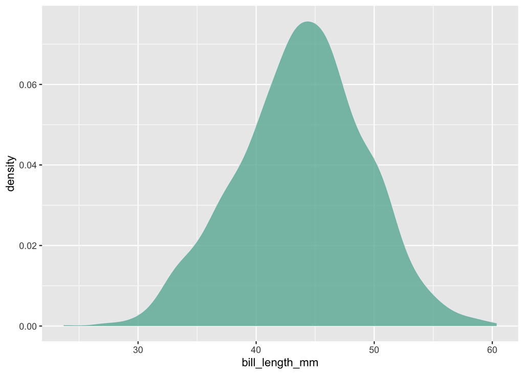

```r
bill_mean <- mean(penguins$bill_length_mm, na.rm = TRUE)
bill_sd <- sd(penguins$bill_length_mm, na.rm = TRUE)

# generate normal distribution from mean and sd
bill_norm <- data.frame(rnorm(1000, mean = bill_mean, sd = bill_sd))
names(bill_norm)[1] <- "bill_length_mm"

bill_norm %>%
  ggplot( aes(x = bill_length_mm)) +
  geom_density(fill="#69b3a2", color="#e9ecef", alpha=0.8)
```

We can also look at the distribution of `bill_length_mm` in our original dataset.

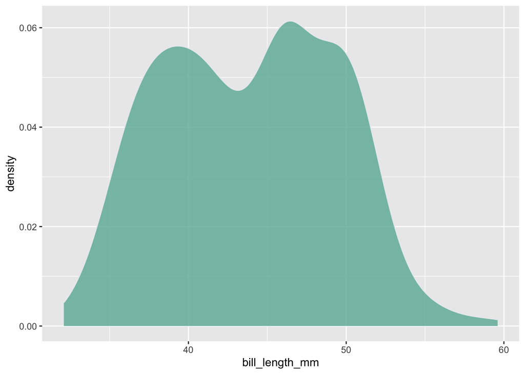

```r
penguins %>%
  ggplot( aes(x = bill_length_mm)) +
  geom_density(fill="#69b3a2", color="#e9ecef", alpha=0.8)
```

Interesting, maybe our data is bimodal?

#### Violins

Alternatively, we could use violin plots to show distribution by species.

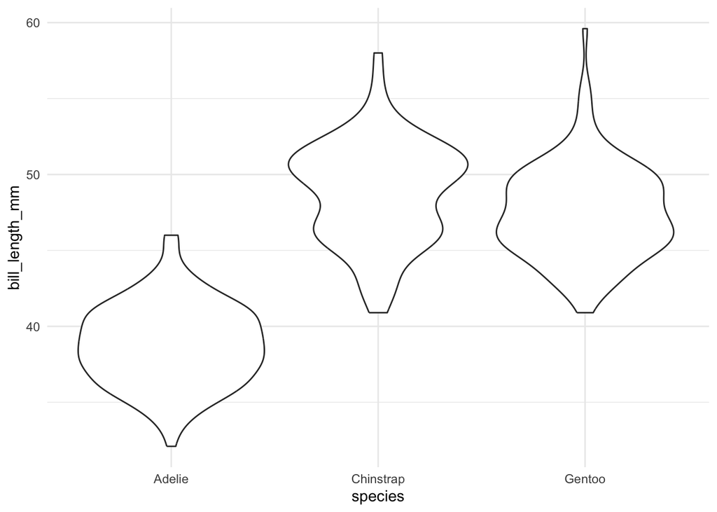

```r
penguins %>%
  ggplot(aes(x = species, y = bill_length_mm)) +
  geom_violin() +
  theme_minimal()
```

Hmm… maybe only two species are bimodal?

### Showing Uncertainty for Multiple Points on a Plot

Now let’s look at something a little more interesting. Let’s say we want to look at mean bill length by species. We can do this with a bar chart:

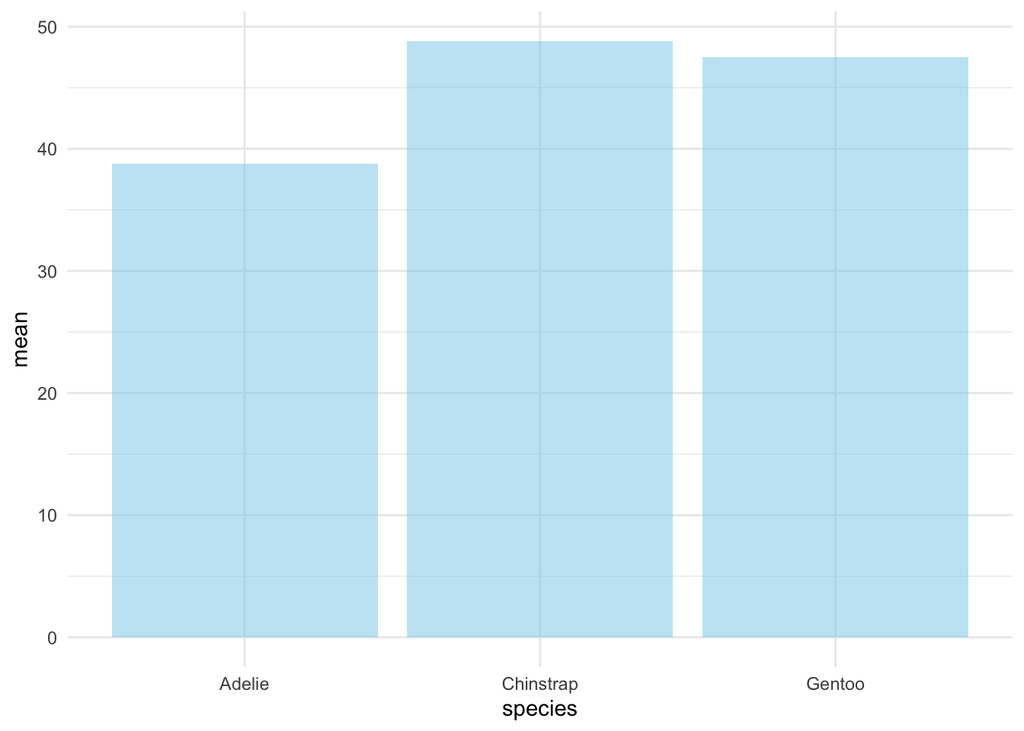

```r
# data wrangling
df <- penguins %>%
  group_by(species) %>%
  summarise(mean = mean(bill_length_mm, na.rm = TRUE),
         sd = sd(bill_length_mm, na.rm = TRUE))

# plotting
df %>%
  ggplot() +
  geom_bar(aes(x = species, y = mean), stat = "identity", fill="skyblue", alpha=0.5) +
  theme_minimal()
```

#### Error Bars

But a bar chart alone won’t show the uncertainty in means. Let’s add error bars:

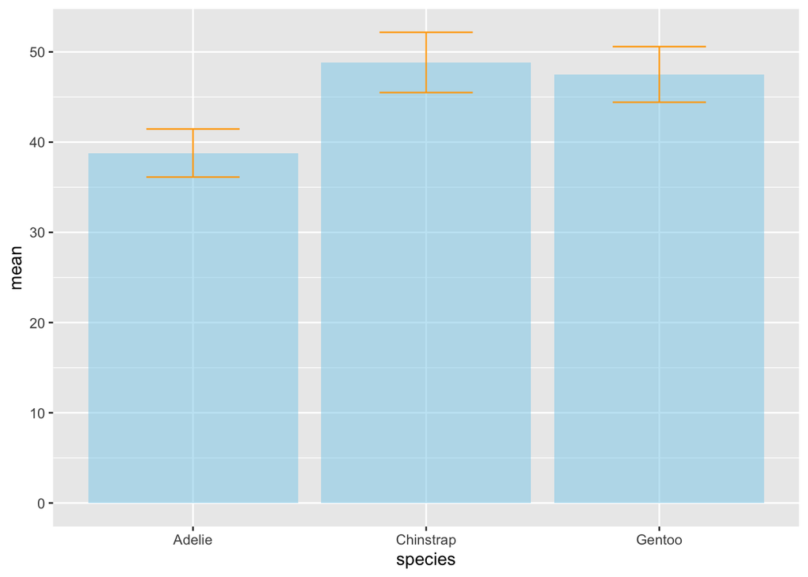

```r
df %>%
  ggplot() +
  geom_bar(aes(x = species, y = mean), stat = "identity", fill = "skyblue", alpha = 0.5) +
  geom_errorbar(aes(x = species, y = mean, ymin = mean - sd, ymax = mean + sd),
                width = 0.4, color = "orange", alpha = 0.9)
```

Try out `geom_crossbar()`, `geom_linerange()`, and `geom_pointrange()` as well.

## Challenge

### HOPs

Hypothetical Outcome Plots show uncertainty through animation that moves between possible outcomes. For example, a HOP that shows mean `bill_length_mm` by `species`, might show a bar for each `species` that varies in height from `mean - sd` to `mean + sd`, according to probabilities from a normal distribution.

Your task for the last part of this demo is to **try** to make a HOP version of the bar chart above. You will need to do some data wrangling, and then look into animation. I recommend starting by clearly mapping out your plan for implementing a HOP. Then, generate the data you will need, and finally look at gganimate to help you animate your plot.